# Risk Factor Analysis

## Outcome Variable

**Outcome Variable:** wast_rec90d

## Predictor Variables

**Intervention Variable:** impsan

**Adjustment Set:**

- arm
- sex
- W_mage
- meducyrs
- feducyrs
- hhwealth_quart
- hfoodsec
- W_mhtcm
- W_nrooms
- W_nchldlt5
- W_parity
- impfloor
- safeh20
- delta_W_mage
- delta_meducyrs
- delta_feducyrs
- delta_hhwealth_quart
- delta_hfoodsec
- delta_W_mhtcm
- delta_W_nrooms
- delta_W_nchldlt5
- delta_W_parity
- delta_impfloor
- delta_safeh20

## Stratifying Variables

The analysis was stratified on these variable(s):

- agecat
- studyid
- country

## Data Summary

| agecat | studyid | country | impsan | wast_rec90d | n_cell | n |
| --- | --- | --- | --- | --- | --- | --- |
| 0-24 months | ki0047075b-MAL-ED | BANGLADESH | 0 | 0 | 10 | 121 |
| 0-24 months | ki0047075b-MAL-ED | BANGLADESH | 0 | 1 | 11 | 121 |
| 0-24 months | ki0047075b-MAL-ED | BANGLADESH | 1 | 0 | 34 | 121 |
| 0-24 months | ki0047075b-MAL-ED | BANGLADESH | 1 | 1 | 66 | 121 |
| 0-24 months | ki0047075b-MAL-ED | BRAZIL | 0 | 0 | 0 | 23 |
| 0-24 months | ki0047075b-MAL-ED | BRAZIL | 0 | 1 | 1 | 23 |
| 0-24 months | ki0047075b-MAL-ED | BRAZIL | 1 | 0 | 6 | 23 |
| 0-24 months | ki0047075b-MAL-ED | BRAZIL | 1 | 1 | 16 | 23 |
| 0-24 months | ki0047075b-MAL-ED | INDIA | 0 | 0 | 40 | 170 |
| 0-24 months | ki0047075b-MAL-ED | INDIA | 0 | 1 | 64 | 170 |
| 0-24 months | ki0047075b-MAL-ED | INDIA | 1 | 0 | 25 | 170 |
| 0-24 months | ki0047075b-MAL-ED | INDIA | 1 | 1 | 41 | 170 |
| 0-24 months | ki0047075b-MAL-ED | NEPAL | 0 | 0 | 0 | 92 |
| 0-24 months | ki0047075b-MAL-ED | NEPAL | 0 | 1 | 0 | 92 |
| 0-24 months | ki0047075b-MAL-ED | NEPAL | 1 | 0 | 19 | 92 |
| 0-24 months | ki0047075b-MAL-ED | NEPAL | 1 | 1 | 73 | 92 |
| 0-24 months | ki0047075b-MAL-ED | PERU | 0 | 0 | 3 | 32 |
| 0-24 months | ki0047075b-MAL-ED | PERU | 0 | 1 | 20 | 32 |
| 0-24 months | ki0047075b-MAL-ED | PERU | 1 | 0 | 3 | 32 |
| 0-24 months | ki0047075b-MAL-ED | PERU | 1 | 1 | 6 | 32 |
| 0-24 months | ki0047075b-MAL-ED | SOUTH AFRICA | 0 | 0 | 11 | 76 |
| 0-24 months | ki0047075b-MAL-ED | SOUTH AFRICA | 0 | 1 | 63 | 76 |
| 0-24 months | ki0047075b-MAL-ED | SOUTH AFRICA | 1 | 0 | 1 | 76 |
| 0-24 months | ki0047075b-MAL-ED | SOUTH AFRICA | 1 | 1 | 1 | 76 |
| 0-24 months | ki0047075b-MAL-ED | TANZANIA, UNITED REPUBLIC OF | 0 | 0 | 8 | 44 |
| 0-24 months | ki0047075b-MAL-ED | TANZANIA, UNITED REPUBLIC OF | 0 | 1 | 36 | 44 |
| 0-24 months | ki0047075b-MAL-ED | TANZANIA, UNITED REPUBLIC OF | 1 | 0 | 0 | 44 |
| 0-24 months | ki0047075b-MAL-ED | TANZANIA, UNITED REPUBLIC OF | 1 | 1 | 0 | 44 |
| 0-24 months | ki1017093-NIH-Birth | BANGLADESH | 0 | 0 | 136 | 421 |
| 0-24 months | ki1017093-NIH-Birth | BANGLADESH | 0 | 1 | 138 | 421 |

[output cut: 174 more lines]

The following strata were considered:

- agecat: 0-24 months, studyid: ki0047075b-MAL-ED, country: BANGLADESH
- agecat: 0-24 months, studyid: ki0047075b-MAL-ED, country: BRAZIL
- agecat: 0-24 months, studyid: ki0047075b-MAL-ED, country: INDIA
- agecat: 0-24 months, studyid: ki0047075b-MAL-ED, country: NEPAL
- agecat: 0-24 months, studyid: ki0047075b-MAL-ED, country: PERU
- agecat: 0-24 months, studyid: ki0047075b-MAL-ED, country: SOUTH AFRICA
- agecat: 0-24 months, studyid: ki0047075b-MAL-ED, country: TANZANIA, UNITED REPUBLIC OF
- agecat: 0-24 months, studyid: ki1017093-NIH-Birth, country: BANGLADESH
- agecat: 0-24 months, studyid: ki1017093b-PROVIDE, country: BANGLADESH
- agecat: 0-24 months, studyid: ki1017093c-NIH-Crypto, country: BANGLADESH
- agecat: 0-24 months, studyid: ki1114097-CONTENT, country: PERU
- agecat: 0-24 months, studyid: ki1135781-COHORTS, country: GUATEMALA
- agecat: 0-24 months, studyid: ki1135781-COHORTS, country: INDIA
- agecat: 0-24 months, studyid: ki1135781-COHORTS, country: PHILIPPINES
- agecat: 0-24 months, studyid: ki1148112-LCNI-5, country: MALAWI
- agecat: 0-24 months, studyid: kiGH5241-JiVitA-3, country: BANGLADESH
- agecat: 0-24 months, studyid: kiGH5241-JiVitA-4, country: BANGLADESH
- agecat: 0-6 months, studyid: ki0047075b-MAL-ED, country: BANGLADESH
- agecat: 0-6 months, studyid: ki0047075b-MAL-ED, country: BRAZIL
- agecat: 0-6 months, studyid: ki0047075b-MAL-ED, country: INDIA
- agecat: 0-6 months, studyid: ki0047075b-MAL-ED, country: NEPAL
- agecat: 0-6 months, studyid: ki0047075b-MAL-ED, country: PERU
- agecat: 0-6 months, studyid: ki0047075b-MAL-ED, country: SOUTH AFRICA
- agecat: 0-6 months, studyid: ki0047075b-MAL-ED, country: TANZANIA, UNITED REPUBLIC OF
- agecat: 0-6 months, studyid: ki1017093-NIH-Birth, country: BANGLADESH
- agecat: 0-6 months, studyid: ki1017093b-PROVIDE, country: BANGLADESH
- agecat: 0-6 months, studyid: ki1017093c-NIH-Crypto, country: BANGLADESH
- agecat: 0-6 months, studyid: ki1114097-CONTENT, country: PERU
- agecat: 0-6 months, studyid: ki1135781-COHORTS, country: GUATEMALA
- agecat: 0-6 months, studyid: ki1135781-COHORTS, country: INDIA
- agecat: 0-6 months, studyid: ki1135781-COHORTS, country: PHILIPPINES
- agecat: 0-6 months, studyid: ki1148112-LCNI-5, country: MALAWI
- agecat: 0-6 months, studyid: kiGH5241-JiVitA-3, country: BANGLADESH
- agecat: 0-6 months, studyid: kiGH5241-JiVitA-4, country: BANGLADESH
- agecat: 6-24 months, studyid: ki0047075b-MAL-ED, country: BANGLADESH
- agecat: 6-24 months, studyid: ki0047075b-MAL-ED, country: BRAZIL
- agecat: 6-24 months, studyid: ki0047075b-MAL-ED, country: INDIA
- agecat: 6-24 months, studyid: ki0047075b-MAL-ED, country: NEPAL
- agecat: 6-24 months, studyid: ki0047075b-MAL-ED, country: PERU
- agecat: 6-24 months, studyid: ki0047075b-MAL-ED, country: SOUTH AFRICA
- agecat: 6-24 months, studyid: ki0047075b-MAL-ED, country: TANZANIA, UNITED REPUBLIC OF
- agecat: 6-24 months, studyid: ki1017093-NIH-Birth, country: BANGLADESH
- agecat: 6-24 months, studyid: ki1017093b-PROVIDE, country: BANGLADESH
- agecat: 6-24 months, studyid: ki1017093c-NIH-Crypto, country: BANGLADESH
- agecat: 6-24 months, studyid: ki1114097-CONTENT, country: PERU
- agecat: 6-24 months, studyid: ki1135781-COHORTS, country: GUATEMALA
- agecat: 6-24 months, studyid: ki1135781-COHORTS, country: INDIA
- agecat: 6-24 months, studyid: ki1135781-COHORTS, country: PHILIPPINES
- agecat: 6-24 months, studyid: ki1148112-LCNI-5, country: MALAWI
- agecat: 6-24 months, studyid: kiGH5241-JiVitA-3, country: BANGLADESH
- agecat: 6-24 months, studyid: kiGH5241-JiVitA-4, country: BANGLADESH

### Dropped Strata

Some strata were dropped due to rare outcomes:

- agecat: 0-24 months, studyid: ki0047075b-MAL-ED, country: BRAZIL
- agecat: 0-24 months, studyid: ki0047075b-MAL-ED, country: NEPAL
- agecat: 0-24 months, studyid: ki0047075b-MAL-ED, country: PERU
- agecat: 0-24 months, studyid: ki0047075b-MAL-ED, country: SOUTH AFRICA
- agecat: 0-24 months, studyid: ki0047075b-MAL-ED, country: TANZANIA, UNITED REPUBLIC OF
- agecat: 0-24 months, studyid: ki1114097-CONTENT, country: PERU
- agecat: 0-24 months, studyid: ki1148112-LCNI-5, country: MALAWI
- agecat: 0-6 months, studyid: ki0047075b-MAL-ED, country: BANGLADESH
- agecat: 0-6 months, studyid: ki0047075b-MAL-ED, country: BRAZIL
- agecat: 0-6 months, studyid: ki0047075b-MAL-ED, country: NEPAL
- agecat: 0-6 months, studyid: ki0047075b-MAL-ED, country: PERU
- agecat: 0-6 months, studyid: ki0047075b-MAL-ED, country: SOUTH AFRICA
- agecat: 0-6 months, studyid: ki0047075b-MAL-ED, country: TANZANIA, UNITED REPUBLIC OF
- agecat: 0-6 months, studyid: ki1017093b-PROVIDE, country: BANGLADESH
- agecat: 0-6 months, studyid: ki1017093c-NIH-Crypto, country: BANGLADESH
- agecat: 0-6 months, studyid: ki1114097-CONTENT, country: PERU
- agecat: 0-6 months, studyid: ki1135781-COHORTS, country: GUATEMALA
- agecat: 0-6 months, studyid: ki1148112-LCNI-5, country: MALAWI
- agecat: 6-24 months, studyid: ki0047075b-MAL-ED, country: BANGLADESH
- agecat: 6-24 months, studyid: ki0047075b-MAL-ED, country: BRAZIL
- agecat: 6-24 months, studyid: ki0047075b-MAL-ED, country: NEPAL
- agecat: 6-24 months, studyid: ki0047075b-MAL-ED, country: PERU
- agecat: 6-24 months, studyid: ki0047075b-MAL-ED, country: SOUTH AFRICA
- agecat: 6-24 months, studyid: ki0047075b-MAL-ED, country: TANZANIA, UNITED REPUBLIC OF
- agecat: 6-24 months, studyid: ki1017093b-PROVIDE, country: BANGLADESH
- agecat: 6-24 months, studyid: ki1017093c-NIH-Crypto, country: BANGLADESH
- agecat: 6-24 months, studyid: ki1114097-CONTENT, country: PERU
- agecat: 6-24 months, studyid: ki1135781-COHORTS, country: GUATEMALA
- agecat: 6-24 months, studyid: ki1135781-COHORTS, country: INDIA
- agecat: 6-24 months, studyid: ki1148112-LCNI-5, country: MALAWI
- agecat: 6-24 months, studyid: kiGH5241-JiVitA-3, country: BANGLADESH

## Methods Detail

We’re interested in the causal parameters $E[Y_a]$ for all values of $a \in \mathcal{A}$. These parameters represent the mean outcome if, possibly contrary to fact, we intervened to set all units to have $A=a$. Under the randomization and positivity assumptions, these are identified by the statistical parameters $\psi_a=E_W[E_{Y|A,W}(Y|A=a,W)]$. In addition, we’re interested in the mean of $Y$, $E[Y]$ under no intervention (the observed mean). We will estimate these parameters by using SuperLearner to fit the relevant likelihood factors – $E_{Y|A,W}(Y|A=a,W)$ and $p(A=a|W)$, and then updating our likelihood fit using a joint TMLE.

For unadjusted analyses ($W=\{\}$), initial likelihoods were estimated using Lrnr_glm to estimate the simple $E(Y|A)$ and Lrnr_mean to estimate $p(A)$. For adjusted analyses, a small library containing Lrnr_glmnet, Lrnr_xgboost, and Lrnr_mean was used.

Having estimated these parameters, we will then use the delta method to estimate relative risks and attributable risks relative to a prespecified baseline level of $A$.

# Results Detail

## Results Plots

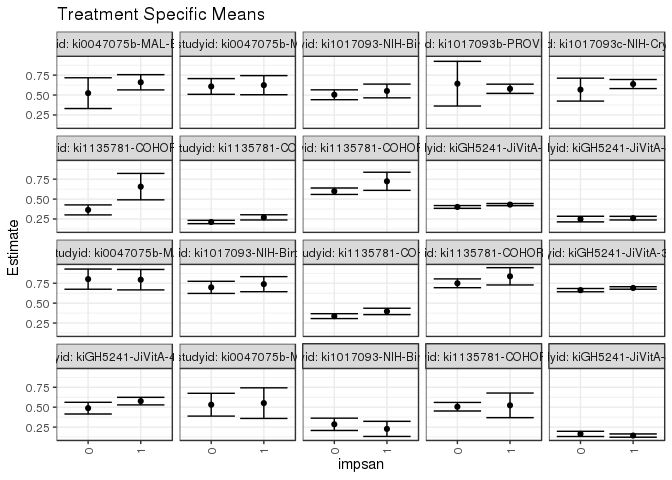

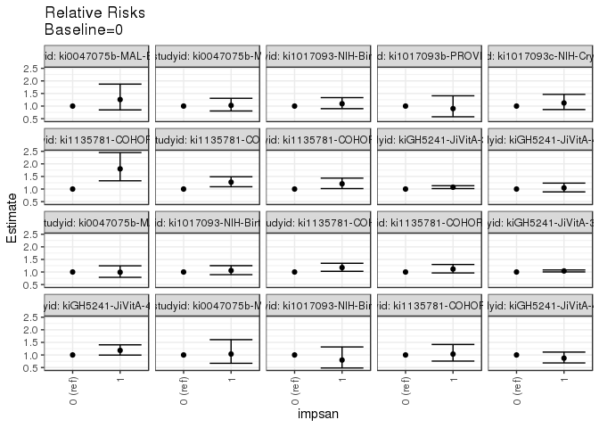

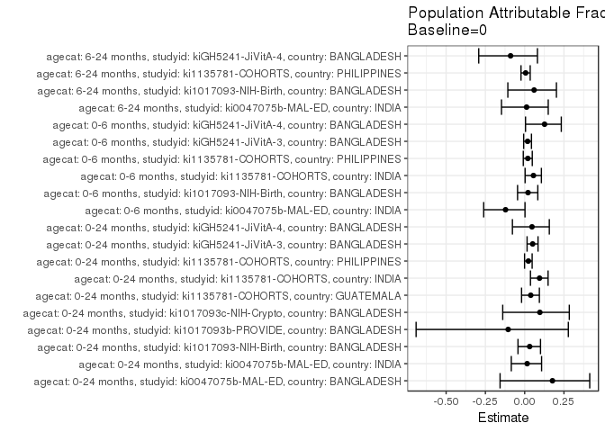

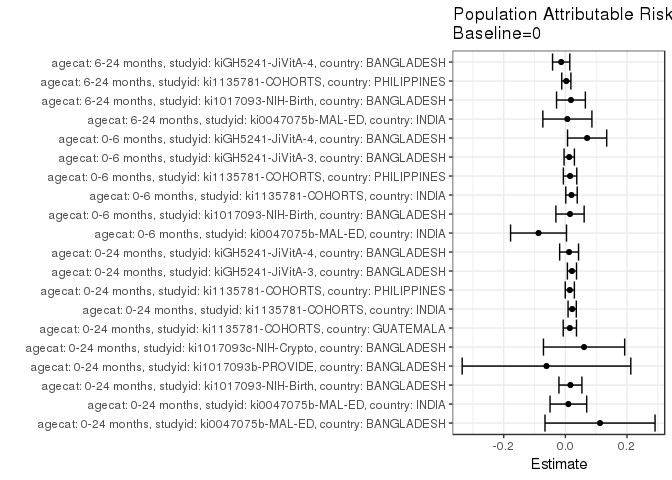

## Results Table

### Parameter: TSM

| agecat | studyid | country | intervention_level | baseline_level | estimate | ci_lower | ci_upper |
| --- | --- | --- | --- | --- | --- | --- | --- |
| 0-24 months | ki0047075b-MAL-ED | BANGLADESH | 0 | NA | 0.5238628 | 0.3308061 | 0.7169196 |
| 0-24 months | ki0047075b-MAL-ED | BANGLADESH | 1 | NA | 0.6601342 | 0.5644178 | 0.7558506 |
| 0-24 months | ki0047075b-MAL-ED | INDIA | 0 | NA | 0.6078136 | 0.5091234 | 0.7065038 |
| 0-24 months | ki0047075b-MAL-ED | INDIA | 1 | NA | 0.6240902 | 0.5040379 | 0.7441426 |
| 0-24 months | ki1017093-NIH-Birth | BANGLADESH | 0 | NA | 0.5036815 | 0.4416364 | 0.5657267 |
| 0-24 months | ki1017093-NIH-Birth | BANGLADESH | 1 | NA | 0.5512583 | 0.4651526 | 0.6373640 |
| 0-24 months | ki1017093b-PROVIDE | BANGLADESH | 0 | NA | 0.6428571 | 0.3621822 | 0.9235321 |
| 0-24 months | ki1017093b-PROVIDE | BANGLADESH | 1 | NA | 0.5787671 | 0.5206376 | 0.6368967 |
| 0-24 months | ki1017093c-NIH-Crypto | BANGLADESH | 0 | NA | 0.5679107 | 0.4240853 | 0.7117362 |
| 0-24 months | ki1017093c-NIH-Crypto | BANGLADESH | 1 | NA | 0.6381985 | 0.5813047 | 0.6950922 |
| 0-24 months | ki1135781-COHORTS | GUATEMALA | 0 | NA | 0.3641870 | 0.3014219 | 0.4269521 |
| 0-24 months | ki1135781-COHORTS | GUATEMALA | 1 | NA | 0.6563420 | 0.4905772 | 0.8221067 |
| 0-24 months | ki1135781-COHORTS | INDIA | 0 | NA | 0.2122695 | 0.1914697 | 0.2330693 |
| 0-24 months | ki1135781-COHORTS | INDIA | 1 | NA | 0.2704322 | 0.2377914 | 0.3030731 |
| 0-24 months | ki1135781-COHORTS | PHILIPPINES | 0 | NA | 0.5989505 | 0.5585364 | 0.6393647 |
| 0-24 months | ki1135781-COHORTS | PHILIPPINES | 1 | NA | 0.7232600 | 0.6094763 | 0.8370437 |
| 0-24 months | kiGH5241-JiVitA-3 | BANGLADESH | 0 | NA | 0.4013629 | 0.3839143 | 0.4188114 |
| 0-24 months | kiGH5241-JiVitA-3 | BANGLADESH | 1 | NA | 0.4307416 | 0.4173667 | 0.4441164 |
| 0-24 months | kiGH5241-JiVitA-4 | BANGLADESH | 0 | NA | 0.2491428 | 0.2140610 | 0.2842245 |
| 0-24 months | kiGH5241-JiVitA-4 | BANGLADESH | 1 | NA | 0.2607855 | 0.2380783 | 0.2834927 |
| 0-6 months | ki0047075b-MAL-ED | INDIA | 0 | NA | 0.8012434 | 0.6746369 | 0.9278499 |
| 0-6 months | ki0047075b-MAL-ED | INDIA | 1 | NA | 0.7942604 | 0.6658887 | 0.9226321 |
| 0-6 months | ki1017093-NIH-Birth | BANGLADESH | 0 | NA | 0.6978417 | 0.6216977 | 0.7739857 |
| 0-6 months | ki1017093-NIH-Birth | BANGLADESH | 1 | NA | 0.7380952 | 0.6434348 | 0.8327557 |
| 0-6 months | ki1135781-COHORTS | INDIA | 0 | NA | 0.3366509 | 0.3062305 | 0.3670713 |
| 0-6 months | ki1135781-COHORTS | INDIA | 1 | NA | 0.3959699 | 0.3559232 | 0.4360167 |
| 0-6 months | ki1135781-COHORTS | PHILIPPINES | 0 | NA | 0.7489177 | 0.6935154 | 0.8043201 |
| 0-6 months | ki1135781-COHORTS | PHILIPPINES | 1 | NA | 0.8367347 | 0.7280039 | 0.9454655 |
| 0-6 months | kiGH5241-JiVitA-3 | BANGLADESH | 0 | NA | 0.6630263 | 0.6425109 | 0.6835416 |
| 0-6 months | kiGH5241-JiVitA-3 | BANGLADESH | 1 | NA | 0.6904074 | 0.6748652 | 0.7059497 |
| 0-6 months | kiGH5241-JiVitA-4 | BANGLADESH | 0 | NA | 0.4877229 | 0.4141617 | 0.5612841 |
| 0-6 months | kiGH5241-JiVitA-4 | BANGLADESH | 1 | NA | 0.5760203 | 0.5284642 | 0.6235764 |
| 6-24 months | ki0047075b-MAL-ED | INDIA | 0 | NA | 0.5310235 | 0.3877103 | 0.6743367 |
| 6-24 months | ki0047075b-MAL-ED | INDIA | 1 | NA | 0.5508372 | 0.3586393 | 0.7430351 |
| 6-24 months | ki1017093-NIH-Birth | BANGLADESH | 0 | NA | 0.2848305 | 0.2075045 | 0.3621564 |
| 6-24 months | ki1017093-NIH-Birth | BANGLADESH | 1 | NA | 0.2272420 | 0.1323906 | 0.3220934 |
| 6-24 months | ki1135781-COHORTS | PHILIPPINES | 0 | NA | 0.5054986 | 0.4517794 | 0.5592178 |
| 6-24 months | ki1135781-COHORTS | PHILIPPINES | 1 | NA | 0.5229027 | 0.3683089 | 0.6774965 |
| 6-24 months | kiGH5241-JiVitA-4 | BANGLADESH | 0 | NA | 0.1644413 | 0.1318593 | 0.1970234 |
| 6-24 months | kiGH5241-JiVitA-4 | BANGLADESH | 1 | NA | 0.1434535 | 0.1229823 | 0.1639247 |

### Parameter: E(Y)

| agecat | studyid | country | intervention_level | baseline_level | estimate | ci_lower | ci_upper |
| --- | --- | --- | --- | --- | --- | --- | --- |
| 0-24 months | ki0047075b-MAL-ED | BANGLADESH | NA | NA | 0.6363636 | 0.5494154 | 0.7233119 |
| 0-24 months | ki0047075b-MAL-ED | INDIA | NA | NA | 0.6176471 | 0.5365376 | 0.6987565 |
| 0-24 months | ki1017093-NIH-Birth | BANGLADESH | NA | NA | 0.5201900 | 0.4695846 | 0.5707955 |
| 0-24 months | ki1017093b-PROVIDE | BANGLADESH | NA | NA | 0.5816993 | 0.5247676 | 0.6386311 |
| 0-24 months | ki1017093c-NIH-Crypto | BANGLADESH | NA | NA | 0.6286645 | 0.5746609 | 0.6826681 |
| 0-24 months | ki1135781-COHORTS | GUATEMALA | NA | NA | 0.3787879 | 0.3179432 | 0.4396325 |
| 0-24 months | ki1135781-COHORTS | INDIA | NA | NA | 0.2344546 | 0.2156201 | 0.2532892 |
| 0-24 months | ki1135781-COHORTS | PHILIPPINES | NA | NA | 0.6134700 | 0.5751620 | 0.6517779 |
| 0-24 months | kiGH5241-JiVitA-3 | BANGLADESH | NA | NA | 0.4228277 | 0.4116994 | 0.4339560 |
| 0-24 months | kiGH5241-JiVitA-4 | BANGLADESH | NA | NA | 0.2613103 | 0.2419607 | 0.2806599 |
| 0-6 months | ki0047075b-MAL-ED | INDIA | NA | NA | 0.7142857 | 0.6098683 | 0.8187031 |
| 0-6 months | ki1017093-NIH-Birth | BANGLADESH | NA | NA | 0.7130045 | 0.6535890 | 0.7724200 |
| 0-6 months | ki1135781-COHORTS | INDIA | NA | NA | 0.3565891 | 0.3304405 | 0.3827378 |
| 0-6 months | ki1135781-COHORTS | PHILIPPINES | NA | NA | 0.7642857 | 0.7146210 | 0.8139505 |
| 0-6 months | kiGH5241-JiVitA-3 | BANGLADESH | NA | NA | 0.6756128 | 0.6622741 | 0.6889516 |
| 0-6 months | kiGH5241-JiVitA-4 | BANGLADESH | NA | NA | 0.5583942 | 0.5167799 | 0.6000084 |
| 6-24 months | ki0047075b-MAL-ED | INDIA | NA | NA | 0.5376344 | 0.4216441 | 0.6536248 |
| 6-24 months | ki1017093-NIH-Birth | BANGLADESH | NA | NA | 0.3030303 | 0.2377927 | 0.3682679 |
| 6-24 months | ki1135781-COHORTS | PHILIPPINES | NA | NA | 0.5086849 | 0.4571562 | 0.5602135 |
| 6-24 months | kiGH5241-JiVitA-4 | BANGLADESH | NA | NA | 0.1508986 | 0.1332882 | 0.1685090 |

### Parameter: RR

| agecat | studyid | country | intervention_level | baseline_level | estimate | ci_lower | ci_upper |
| --- | --- | --- | --- | --- | --- | --- | --- |
| 0-24 months | ki0047075b-MAL-ED | BANGLADESH | 0 | 0 | 1.0000000 | 1.0000000 | 1.000000 |
| 0-24 months | ki0047075b-MAL-ED | BANGLADESH | 1 | 0 | 1.2601280 | 0.8481283 | 1.872267 |
| 0-24 months | ki0047075b-MAL-ED | INDIA | 0 | 0 | 1.0000000 | 1.0000000 | 1.000000 |
| 0-24 months | ki0047075b-MAL-ED | INDIA | 1 | 0 | 1.0267790 | 0.8053238 | 1.309132 |
| 0-24 months | ki1017093-NIH-Birth | BANGLADESH | 0 | 0 | 1.0000000 | 1.0000000 | 1.000000 |
| 0-24 months | ki1017093-NIH-Birth | BANGLADESH | 1 | 0 | 1.0944581 | 0.8973372 | 1.334881 |
| 0-24 months | ki1017093b-PROVIDE | BANGLADESH | 0 | 0 | 1.0000000 | 1.0000000 | 1.000000 |
| 0-24 months | ki1017093b-PROVIDE | BANGLADESH | 1 | 0 | 0.9003044 | 0.5752332 | 1.409077 |
| 0-24 months | ki1017093c-NIH-Crypto | BANGLADESH | 0 | 0 | 1.0000000 | 1.0000000 | 1.000000 |
| 0-24 months | ki1017093c-NIH-Crypto | BANGLADESH | 1 | 0 | 1.1237654 | 0.8619716 | 1.465070 |
| 0-24 months | ki1135781-COHORTS | GUATEMALA | 0 | 0 | 1.0000000 | 1.0000000 | 1.000000 |
| 0-24 months | ki1135781-COHORTS | GUATEMALA | 1 | 0 | 1.8022116 | 1.3266376 | 2.448270 |
| 0-24 months | ki1135781-COHORTS | INDIA | 0 | 0 | 1.0000000 | 1.0000000 | 1.000000 |
| 0-24 months | ki1135781-COHORTS | INDIA | 1 | 0 | 1.2740044 | 1.0912859 | 1.487316 |
| 0-24 months | ki1135781-COHORTS | PHILIPPINES | 0 | 0 | 1.0000000 | 1.0000000 | 1.000000 |
| 0-24 months | ki1135781-COHORTS | PHILIPPINES | 1 | 0 | 1.2075454 | 1.0175337 | 1.433039 |
| 0-24 months | kiGH5241-JiVitA-3 | BANGLADESH | 0 | 0 | 1.0000000 | 1.0000000 | 1.000000 |
| 0-24 months | kiGH5241-JiVitA-3 | BANGLADESH | 1 | 0 | 1.0731973 | 1.0178859 | 1.131514 |
| 0-24 months | kiGH5241-JiVitA-4 | BANGLADESH | 0 | 0 | 1.0000000 | 1.0000000 | 1.000000 |
| 0-24 months | kiGH5241-JiVitA-4 | BANGLADESH | 1 | 0 | 1.0467312 | 0.8869066 | 1.235357 |
| 0-6 months | ki0047075b-MAL-ED | INDIA | 0 | 0 | 1.0000000 | 1.0000000 | 1.000000 |
| 0-6 months | ki0047075b-MAL-ED | INDIA | 1 | 0 | 0.9912848 | 0.7885907 | 1.246078 |
| 0-6 months | ki1017093-NIH-Birth | BANGLADESH | 0 | 0 | 1.0000000 | 1.0000000 | 1.000000 |
| 0-6 months | ki1017093-NIH-Birth | BANGLADESH | 1 | 0 | 1.0576829 | 0.8937715 | 1.251654 |
| 0-6 months | ki1135781-COHORTS | INDIA | 0 | 0 | 1.0000000 | 1.0000000 | 1.000000 |
| 0-6 months | ki1135781-COHORTS | INDIA | 1 | 0 | 1.1762034 | 1.0274190 | 1.346534 |
| 0-6 months | ki1135781-COHORTS | PHILIPPINES | 0 | 0 | 1.0000000 | 1.0000000 | 1.000000 |
| 0-6 months | ki1135781-COHORTS | PHILIPPINES | 1 | 0 | 1.1172585 | 0.9620873 | 1.297457 |
| 0-6 months | kiGH5241-JiVitA-3 | BANGLADESH | 0 | 0 | 1.0000000 | 1.0000000 | 1.000000 |
| 0-6 months | kiGH5241-JiVitA-3 | BANGLADESH | 1 | 0 | 1.0412973 | 1.0026955 | 1.081385 |
| 0-6 months | kiGH5241-JiVitA-4 | BANGLADESH | 0 | 0 | 1.0000000 | 1.0000000 | 1.000000 |
| 0-6 months | kiGH5241-JiVitA-4 | BANGLADESH | 1 | 0 | 1.1810400 | 0.9948131 | 1.402128 |
| 6-24 months | ki0047075b-MAL-ED | INDIA | 0 | 0 | 1.0000000 | 1.0000000 | 1.000000 |
| 6-24 months | ki0047075b-MAL-ED | INDIA | 1 | 0 | 1.0373122 | 0.6692443 | 1.607808 |
| 6-24 months | ki1017093-NIH-Birth | BANGLADESH | 0 | 0 | 1.0000000 | 1.0000000 | 1.000000 |
| 6-24 months | ki1017093-NIH-Birth | BANGLADESH | 1 | 0 | 0.7978151 | 0.4825820 | 1.318965 |
| 6-24 months | ki1135781-COHORTS | PHILIPPINES | 0 | 0 | 1.0000000 | 1.0000000 | 1.000000 |
| 6-24 months | ki1135781-COHORTS | PHILIPPINES | 1 | 0 | 1.0344296 | 0.7555803 | 1.416189 |
| 6-24 months | kiGH5241-JiVitA-4 | BANGLADESH | 0 | 0 | 1.0000000 | 1.0000000 | 1.000000 |
| 6-24 months | kiGH5241-JiVitA-4 | BANGLADESH | 1 | 0 | 0.8723689 | 0.6833033 | 1.113748 |

### Parameter: PAR

| agecat | studyid | country | intervention_level | baseline_level | estimate | ci_lower | ci_upper |
| --- | --- | --- | --- | --- | --- | --- | --- |
| 0-24 months | ki0047075b-MAL-ED | BANGLADESH | 0 | NA | 0.1125008 | -0.0660414 | 0.2910430 |
| 0-24 months | ki0047075b-MAL-ED | INDIA | 0 | NA | 0.0098334 | -0.0496439 | 0.0693108 |
| 0-24 months | ki1017093-NIH-Birth | BANGLADESH | 0 | NA | 0.0165085 | -0.0207364 | 0.0537534 |
| 0-24 months | ki1017093b-PROVIDE | BANGLADESH | 0 | NA | -0.0611578 | -0.3347113 | 0.2123957 |
| 0-24 months | ki1017093c-NIH-Crypto | BANGLADESH | 0 | NA | 0.0607538 | -0.0709864 | 0.1924939 |
| 0-24 months | ki1135781-COHORTS | GUATEMALA | 0 | NA | 0.0146009 | -0.0069291 | 0.0361309 |
| 0-24 months | ki1135781-COHORTS | INDIA | 0 | NA | 0.0221852 | 0.0088136 | 0.0355567 |
| 0-24 months | ki1135781-COHORTS | PHILIPPINES | 0 | NA | 0.0145194 | -0.0002733 | 0.0293121 |
| 0-24 months | kiGH5241-JiVitA-3 | BANGLADESH | 0 | NA | 0.0214648 | 0.0066890 | 0.0362406 |
| 0-24 months | kiGH5241-JiVitA-4 | BANGLADESH | 0 | NA | 0.0121675 | -0.0184847 | 0.0428197 |
| 0-6 months | ki0047075b-MAL-ED | INDIA | 0 | NA | -0.0869577 | -0.1777043 | 0.0037889 |
| 0-6 months | ki1017093-NIH-Birth | BANGLADESH | 0 | NA | 0.0151628 | -0.0306737 | 0.0609992 |
| 0-6 months | ki1135781-COHORTS | INDIA | 0 | NA | 0.0199382 | 0.0013678 | 0.0385087 |
| 0-6 months | ki1135781-COHORTS | PHILIPPINES | 0 | NA | 0.0153680 | -0.0063811 | 0.0371170 |
| 0-6 months | kiGH5241-JiVitA-3 | BANGLADESH | 0 | NA | 0.0125866 | -0.0042142 | 0.0293874 |
| 0-6 months | kiGH5241-JiVitA-4 | BANGLADESH | 0 | NA | 0.0706712 | 0.0071772 | 0.1341653 |
| 6-24 months | ki0047075b-MAL-ED | INDIA | 0 | NA | 0.0066109 | -0.0729788 | 0.0862006 |
| 6-24 months | ki1017093-NIH-Birth | BANGLADESH | 0 | NA | 0.0181998 | -0.0285694 | 0.0649691 |
| 6-24 months | ki1135781-COHORTS | PHILIPPINES | 0 | NA | 0.0031863 | -0.0116722 | 0.0180447 |
| 6-24 months | kiGH5241-JiVitA-4 | BANGLADESH | 0 | NA | -0.0135427 | -0.0415058 | 0.0144203 |

### Parameter: PAF

| agecat | studyid | country | intervention_level | baseline_level | estimate | ci_lower | ci_upper |
| --- | --- | --- | --- | --- | --- | --- | --- |
| 0-24 months | ki0047075b-MAL-ED | BANGLADESH | 0 | NA | 0.1767870 | -0.1566097 | 0.4140809 |
| 0-24 months | ki0047075b-MAL-ED | INDIA | 0 | NA | 0.0159208 | -0.0851799 | 0.1076025 |
| 0-24 months | ki1017093-NIH-Birth | BANGLADESH | 0 | NA | 0.0317355 | -0.0425616 | 0.1007380 |
| 0-24 months | ki1017093b-PROVIDE | BANGLADESH | 0 | NA | -0.1051364 | -0.6911138 | 0.2777975 |
| 0-24 months | ki1017093c-NIH-Crypto | BANGLADESH | 0 | NA | 0.0966394 | -0.1397270 | 0.2839861 |
| 0-24 months | ki1135781-COHORTS | GUATEMALA | 0 | NA | 0.0385464 | -0.0197970 | 0.0935519 |
| 0-24 months | ki1135781-COHORTS | INDIA | 0 | NA | 0.0946245 | 0.0368490 | 0.1489344 |
| 0-24 months | ki1135781-COHORTS | PHILIPPINES | 0 | NA | 0.0236677 | -0.0007212 | 0.0474623 |
| 0-24 months | kiGH5241-JiVitA-3 | BANGLADESH | 0 | NA | 0.0507649 | 0.0153012 | 0.0849513 |
| 0-24 months | kiGH5241-JiVitA-4 | BANGLADESH | 0 | NA | 0.0465635 | -0.0780431 | 0.1567673 |
| 0-6 months | ki0047075b-MAL-ED | INDIA | 0 | NA | -0.1217408 | -0.2608596 | 0.0020282 |
| 0-6 months | ki1017093-NIH-Birth | BANGLADESH | 0 | NA | 0.0212660 | -0.0452626 | 0.0835602 |
| 0-6 months | ki1135781-COHORTS | INDIA | 0 | NA | 0.0559138 | 0.0026633 | 0.1063211 |
| 0-6 months | ki1135781-COHORTS | PHILIPPINES | 0 | NA | 0.0201076 | -0.0088778 | 0.0482603 |
| 0-6 months | kiGH5241-JiVitA-3 | BANGLADESH | 0 | NA | 0.0186299 | -0.0065250 | 0.0431561 |
| 0-6 months | kiGH5241-JiVitA-4 | BANGLADESH | 0 | NA | 0.1265616 | 0.0053901 | 0.2329710 |
| 6-24 months | ki0047075b-MAL-ED | INDIA | 0 | NA | 0.0122963 | -0.1475629 | 0.1498866 |
| 6-24 months | ki1017093-NIH-Birth | BANGLADESH | 0 | NA | 0.0600594 | -0.1071523 | 0.2020174 |
| 6-24 months | ki1135781-COHORTS | PHILIPPINES | 0 | NA | 0.0062638 | -0.0233906 | 0.0350588 |
| 6-24 months | kiGH5241-JiVitA-4 | BANGLADESH | 0 | NA | -0.0897472 | -0.2924794 | 0.0811854 |